# Data profiling

Kevin Solano Ayala

05/09/2020

Reading json data sample

```r
jsondata <- fromJSON(file = "E:/data-sample.json")
```

Data schema

```r
str(jsondata[[1]])
```

```
## List of 8
##  $ id        : chr "806a2843-d6fa-423f-a7f4-e62247efefcf"
##  $ adverts   :List of 5
##   ..$ id                 : chr "be1c0370-a286-4b4e-a644-de4e192dd17d"
##   ..$ activeDays         : num 26
##   ..$ applyUrl           : chr "https://cbc.ca/felis/sed/lacus/morbi.png?ultrices=quis&posuere=orci&cubilia=eget&curae=orci&duis=vehicula&fauci"| __truncated__
##   ..$ publicationDateTime: chr "1379014297"
##   ..$ status             : chr "Active"
##  $ benefits  : chr [1:4] "Home Office" "Phone" "Car" "Dental Plan"
##  $ company   : chr "Bergnaum-Pagac"
##  $ sector    : chr "Engineering"
##  $ title     : chr "Associate Professor"
##  $ city      : chr "Xinxu"
##  $ applicants:List of 1
##   ..$ :List of 5
##   .. ..$ firstName      : chr "Wolf"
##   .. ..$ lastName       : chr "Gladden"
##   .. ..$ skills         : chr [1:5] "Luciferase Assay" "JCreator" "PgSQL" "Economic Research" ...
##   .. ..$ age            : num 23
##   .. ..$ applicationDate: chr "1379273497"
```

Summary

```r
 knitr::kable(dfdp)
```

| Field | Type | Total.Records | Unique.Values | Min.Value | Max.Value | Max.Length.Value |
| --- | --- | --- | --- | --- | --- | --- |
| id | character | 300 | 300 | 004df3fb-6f80-4807-b9ee-1cbf59d34c4d | ff7cc589-bb4d-4f1f-b0d5-fd09441e3dd5 | 36 |
| adverts.id | character | 300 | 300 | 00a8eb80-4f97-4298-8b65-65675acbb7e3 | fff211be-29f7-4305-a34a-6a1a34d25458 | 36 |
| adverts.activeDays | numeric | 300 | 30 | 1 | 30 | 2 |
| adverts.applyUrl | character | 300 | 300 | … | … | 1375 |
| adverts.publicationDateTime | datetime | 300 | 300 | 2010-09-04 22:38:53 | 2020-08-20 18:15:40 | 19 |
| adverts.status | character | 300 | 3 | Active | Inactive | 8 |
| benefits | character | 1200 | 5 | Car | Phone | 17 |
| company | character | 300 | 297 | Abernathy, Haag and Wisozk | Zemlak-Gorczany | 33 |
| sector | character | 283 | 12 | Accounting | Training | 24 |
| title | character | 283 | 126 | Account Executive | Web Developer IV | 36 |
| city | character | 260 | 258 | ‘Arab ar Rashāydah | Zheyuan | 20 |
| applicants.firstName | character | 1829 | 1637 | Aaren | Zelig | 15 |
| applicants.lastName | character | 1829 | 1784 | Abry | Zuann | 15 |
| applicants.skills | character | 9145 | 4703 | .htaccess | Zyxel | 49 |
| applicants.age | numeric | 1829 | 48 | 18 | 65 | 2 |
| applicants.applicationDate | datetime | 1829 | 1335 | 2010-09-05 22:38:53 | 2020-08-30 06:11:05 | 19 |

Metrics

```r
 knitr::kable(data.frame("Metrics" = c("Mean", "Median", "Standard Error", "Standard deviation", "Variance"),
                        "adverts.activeDays" =round(c(mean(df_a_activedays$field),
                                        median(df_a_activedays$field),
                                        std.error(df_a_activedays$field),
                                        sd(df_a_activedays$field),
                                        var(df_a_activedays$field)),2),
                        "applicants.age" =round(c(mean(df_a_age$field),
                                           median(df_a_age$field),
                                           std.error(df_a_age$field),
                                           sd(df_a_age$field),
                                           var(df_a_age$field)),2)
))
```

| Metrics | adverts.activeDays | applicants.age |
| --- | --- | --- |
| Mean | 15.19 | 41.70 |
| Median | 15.00 | 42.00 |
| Standard Error | 0.49 | 0.32 |
| Standard deviation | 8.42 | 13.77 |
| Variance | 70.89 | 189.48 |

```r
summary(c(df_a_activedays$field, df_a_age$field))
```

```
##    Min. 1st Qu.  Median    Mean 3rd Qu.    Max.
##    1.00   25.00   38.00   37.96   52.00   65.00
```

Data visualization

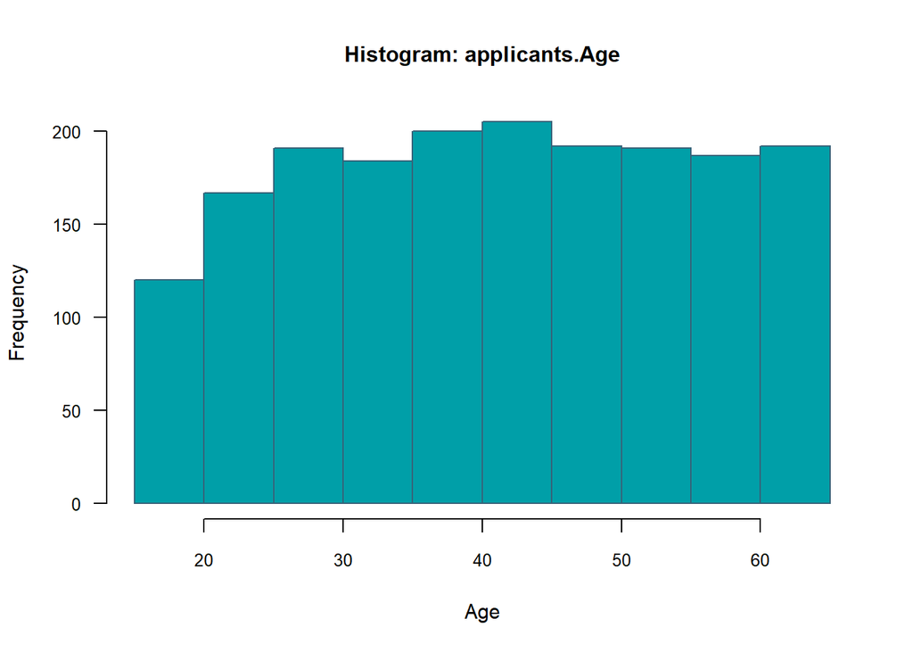

```r
hist(df_a_age$field,
     main="Histogram: applicants.Age",
     xlab="Age",
     ylab="Frequency",
     border="#376278",
     col="#009fa8",
     cex.main=1,
     cex.lab=0.95,
     cex.axis=0.8,
     las=1,
     breaks=10)
```

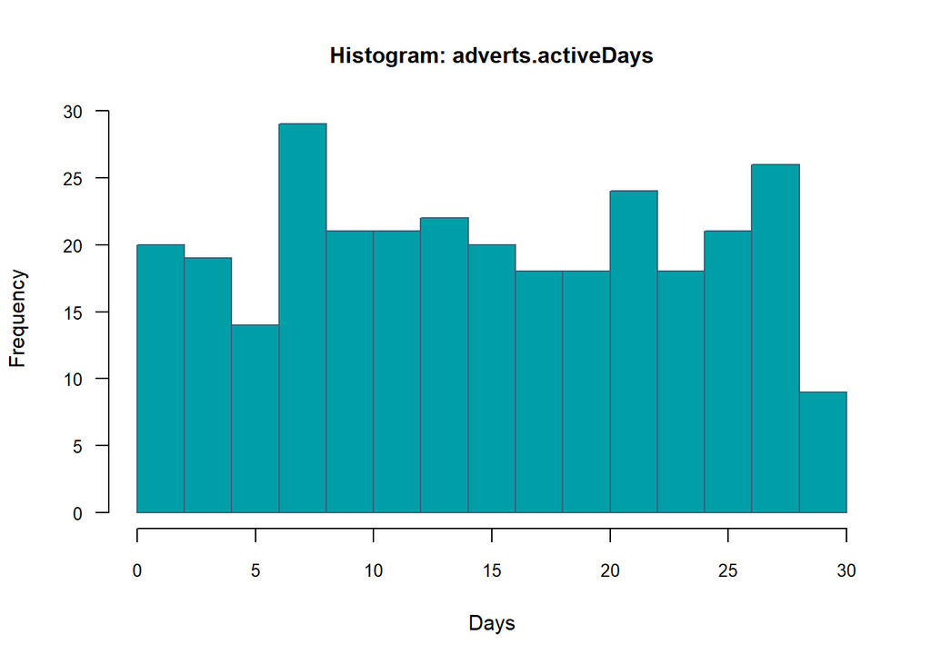

```r
hist(df_a_activedays$field,
     main="Histogram: adverts.activeDays",
     xlab="Days",
     ylab="Frequency",
     border="#376278",
     col="#009fa8",
     cex.main=1,
     cex.lab=0.95,
     cex.axis=0.8,
     las=1,
     breaks=20)
```

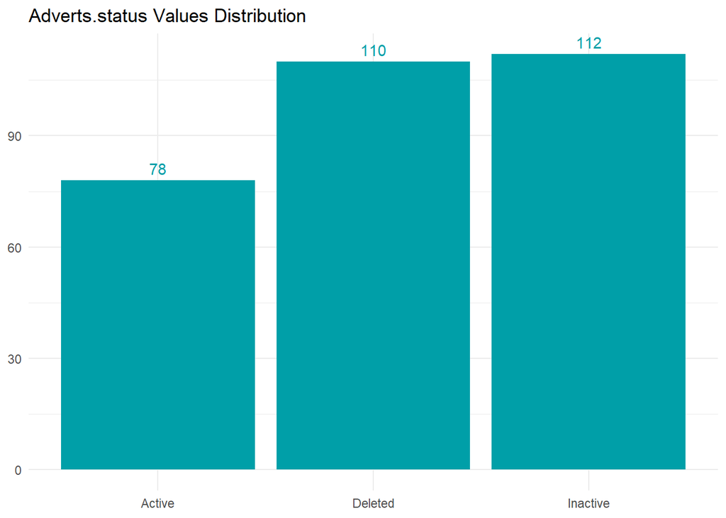

```r
ggplot(data=df_a_status, aes(x=field)) +
  geom_bar(fill="#009fa8")+
  geom_text(aes(label=..count.., group=1),
            stat='count',
            vjust=-0.5,
            color="#009fa8")+
  theme_minimal()+
  theme(axis.title=element_blank())+
  labs(title='Adverts.status Values Distribution')
```

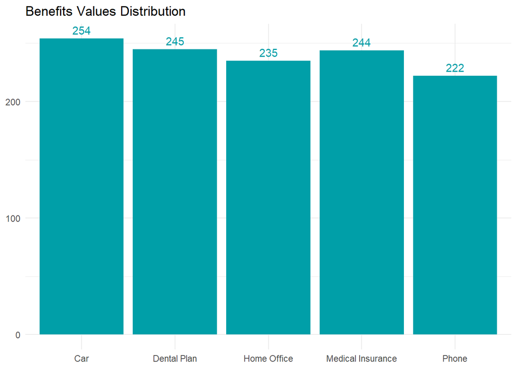

```r
ggplot(data=df_benefits, aes(x=field)) +
  geom_bar(fill="#009fa8")+
  geom_text(aes(label=..count.., group=1),
            stat='count',
            vjust=-0.5,
            color="#009fa8")+
  theme_minimal()+
  theme(axis.title=element_blank())+
  labs(title='Benefits Values Distribution')
```

[figure not shown]

```r
ggplot(data=df_sector, aes(x=field)) +
  geom_bar(fill="#009fa8")+
  geom_text(aes(label=..count.., group=1),
            stat='count',
            vjust=-0.5,
            color="#009fa8")+
  theme_minimal()+
  theme(axis.title=element_blank())+
  labs(title='Sector Values Distribution')
```